# GG_Plot_Class Assesment_Saiifi Haider-PGA19

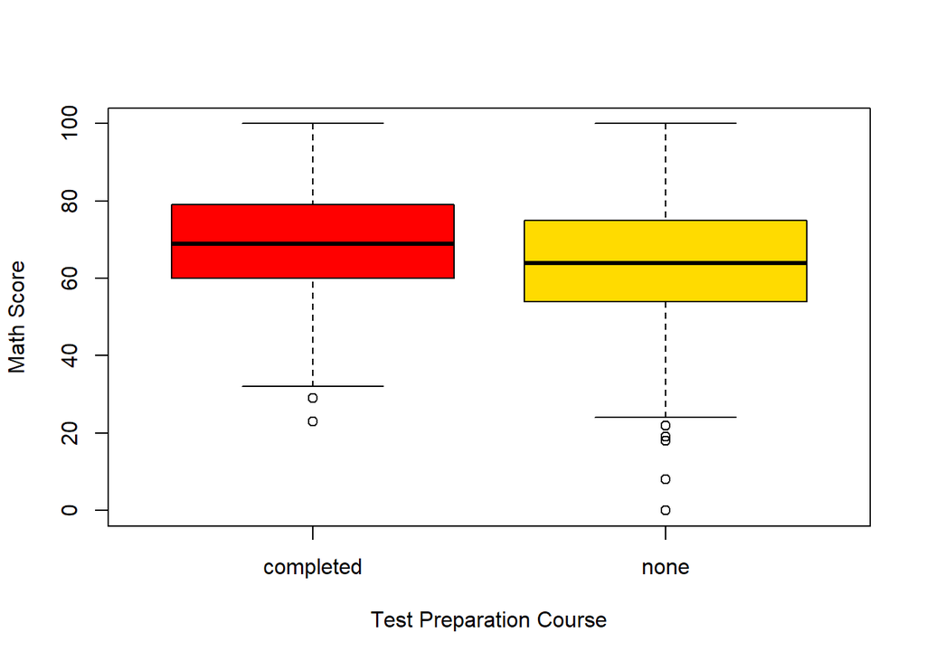

```r
boxplot(math.score~test.preparation.course,data=df, col=rainbow(7), xlab="Test Preparation Course", ylab="Math Score")
```

**From this box plot we can see that except of some outliers students who completed the test preparation course have higher median of math score than students who did not complete the course.**

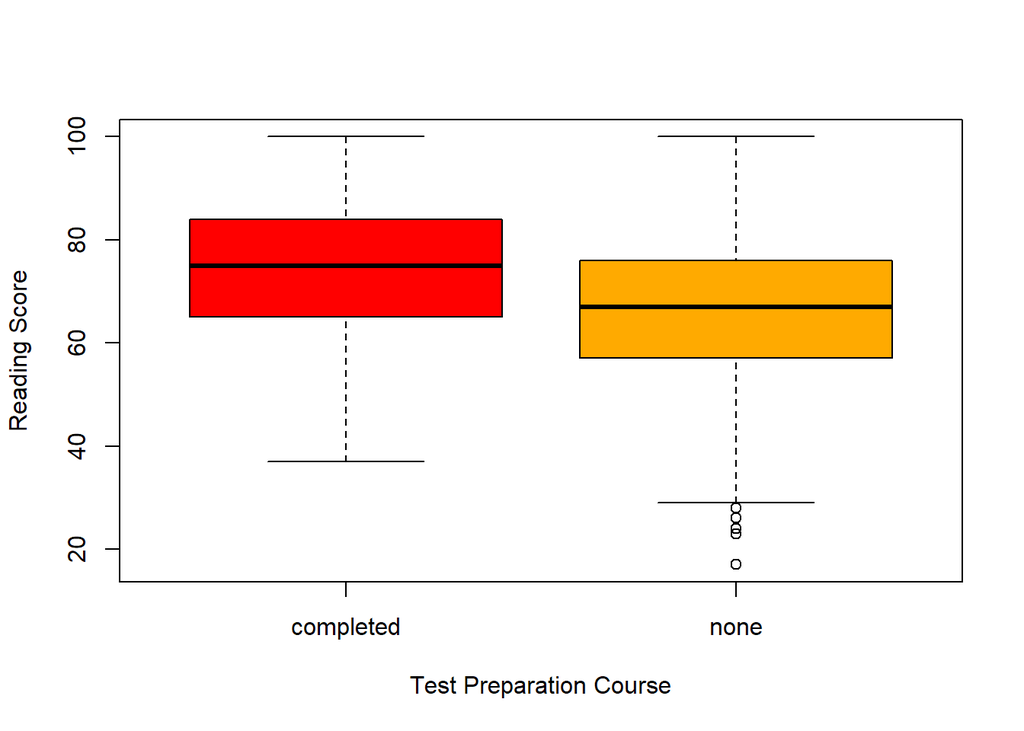

```r
boxplot(reading.score~test.preparation.course,data=df, col=rainbow(9), xlab="Test Preparation Course", ylab="Reading Score")
```

**From this box plot, we can see that except of some outliers students who completed the test preparation course have higher median of reading score than students who did not complete the course.**

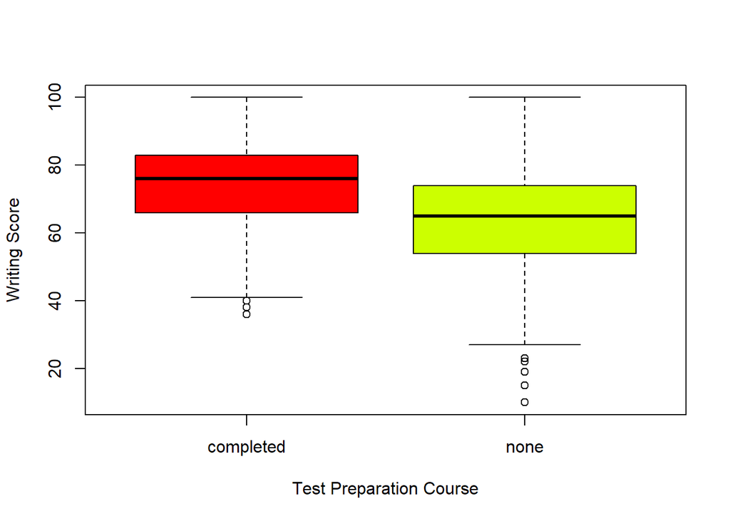

```r
boxplot(writing.score~test.preparation.course,data=df, col=rainbow(5), xlab="Test Preparation Course", ylab="Writing Score")
```

**From this boxplot we can see that except of some outliers students who completed the test preparation course have higher median of writing score than students who did not complete the course.**

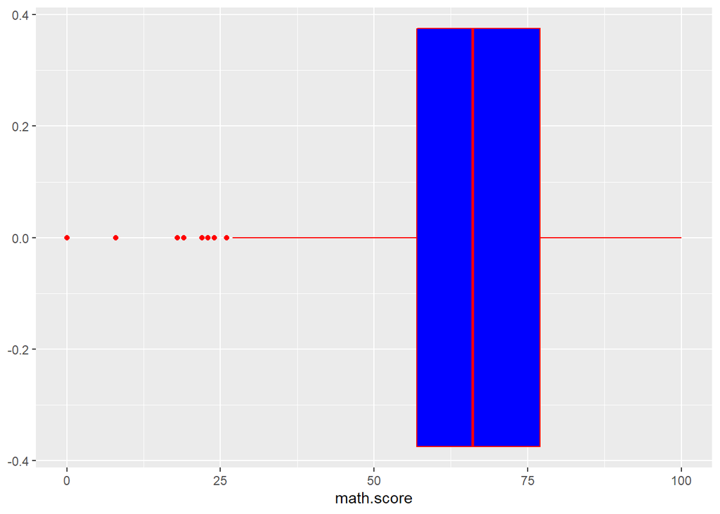

```r
ggplot(data = df,aes(x=math.score)) + geom_boxplot( fill = "blue",col = "red")
```

```r
Q1 <- quantile(df$math.score, .25)
Q3 <- quantile(df$math.score, .75)
IQR <- IQR(df$math.score)
```

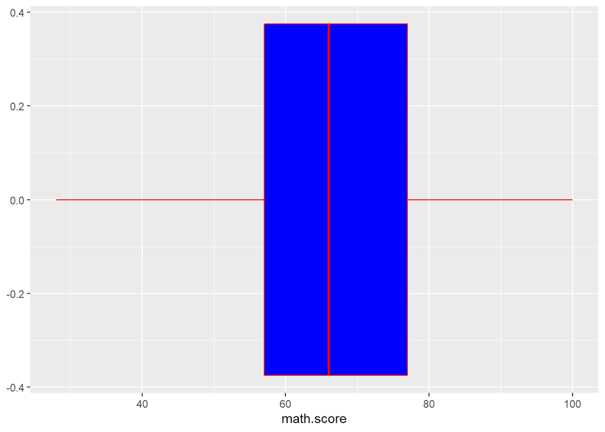

```r
m_outliers <- subset(df, df$math.score> (Q1 - 1.5*IQR) & df$math.score< (Q3 + 1.5*IQR))

ggplot(data = m_outliers, aes(x=math.score)) + geom_boxplot( fill = "blue",col = "red") #we remove the outliers
```

#### *for reading score*

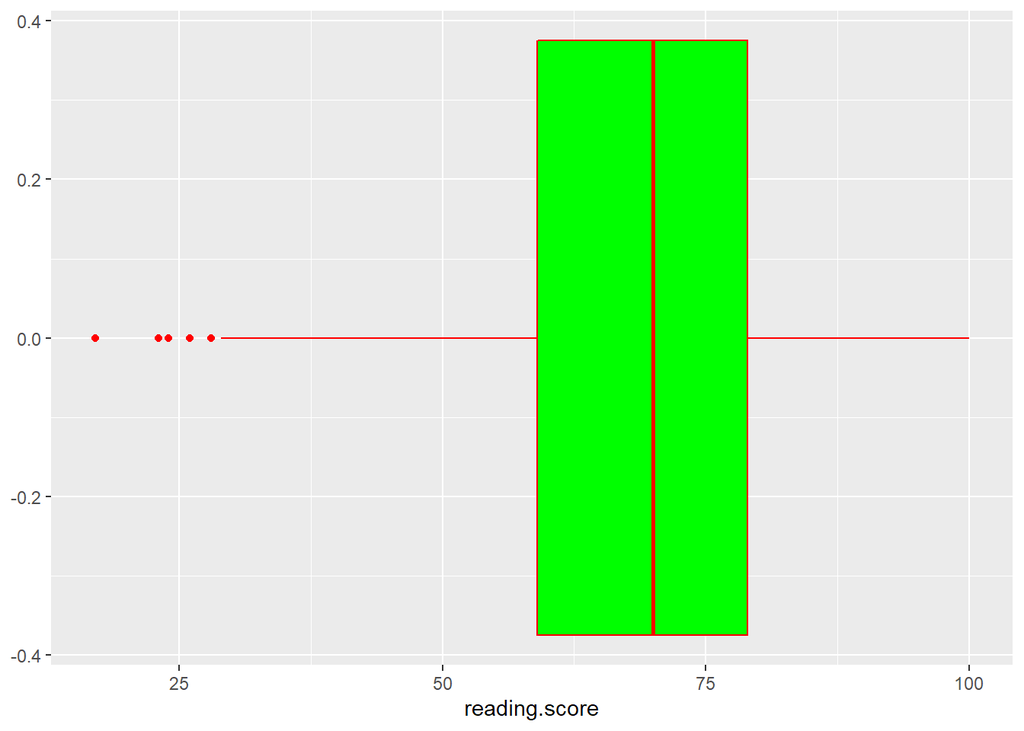

```r
ggplot(data = df,aes(x=reading.score)) + geom_boxplot( fill = "green",col = "red")
```

```r
Q1 <- quantile(df$reading.score, .25)
Q3 <- quantile(df$reading.score, .75)
IQR <- IQR(df$reading.score)
```

#### *Removing outliers*

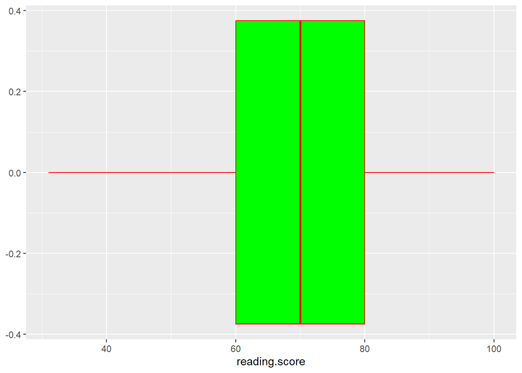

```r
r_outliers <- subset(df, df$reading.score> (Q1 - 1.5*IQR) & df$reading.score< (Q3 + 1.5*IQR))

ggplot(data = r_outliers, aes(x=reading.score)) + geom_boxplot( fill = "green",col = "red")
```

#### *for writing score*

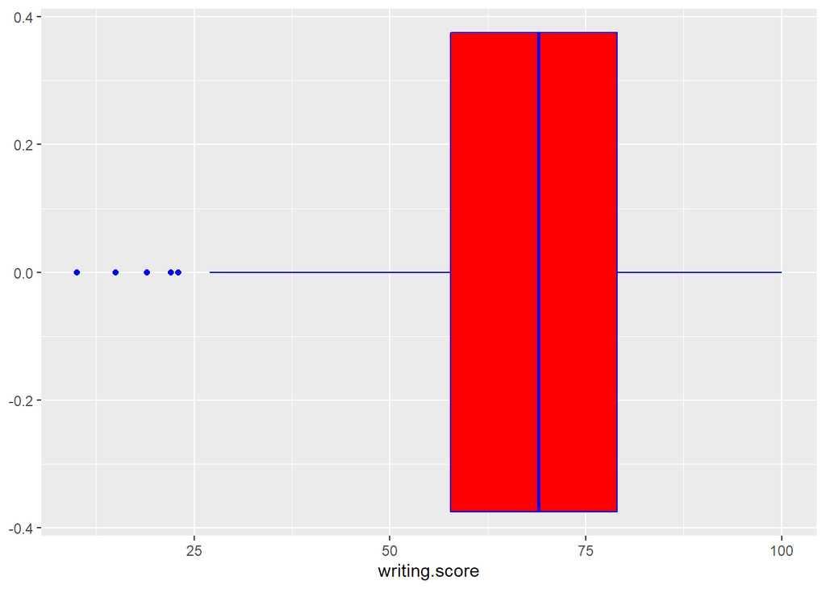

```r
ggplot(data = df,aes(x=writing.score)) + geom_boxplot( fill = "red",col = "blue")
```

```r
Q1 <- quantile(df$writing.score, .25)
Q3 <- quantile(df$writing.score, .75)
IQR <- IQR(df$writing.score)
```

#### *Removing outliers*

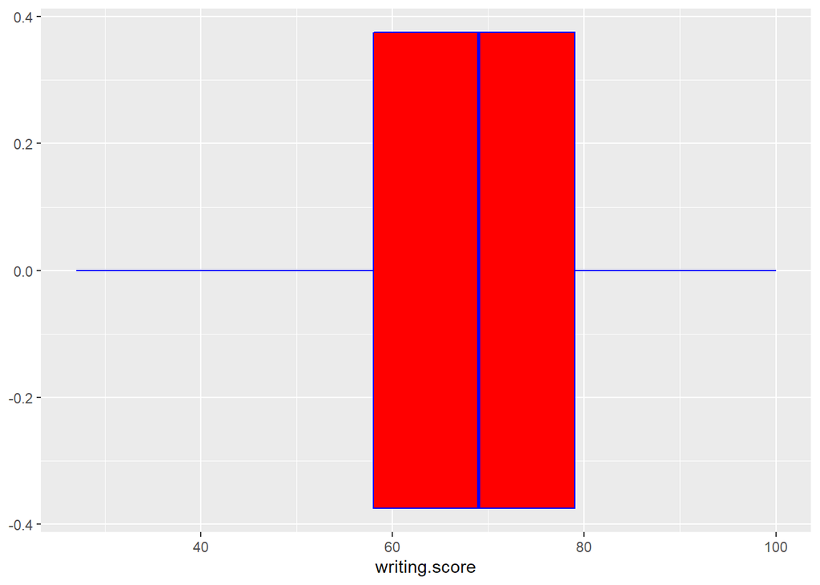

```r
w_outliers <- subset(df, df$writing.score> (Q1 - 1.5*IQR) & df$writing.score< (Q3 + 1.5*IQR))

ggplot(data = w_outliers, aes(x=writing.score)) + geom_boxplot( fill = "red",col = "blue")
```

### Question 3) For the given ‘chinook’ database, perform the following tasks:

#### (I) Connect to the above database and convert all the tables into data frame.

**To connect, we need to install the packages named as ‘RSQLite’,‘DBI’**

```r
setwd("D:/Imarticus/Exam_Assesment_section/R_Programming/R Programming/Dataset")
library("RSQLite")
library("DBI")
db=dbConnect(SQLite(),dbname="chinook.db")
dbListTables(db)
```

```
##  [1] "albums"          "artists"         "customers"       "employees"
##  [5] "genres"          "invoice_items"   "invoices"        "media_types"
##  [9] "playlist_track"  "playlists"       "sqlite_sequence" "sqlite_stat1"
## [13] "tracks"
```

```r
dbListFields(db,"employees")
```

```
##  [1] "EmployeeId" "LastName"   "FirstName"  "Title"      "ReportsTo"
##  [6] "BirthDate"  "HireDate"   "Address"    "City"       "State"
## [11] "Country"    "PostalCode" "Phone"      "Fax"        "Email"
```

#### (II) Print the different types of music available.

```r
Type_of_music <- dbGetQuery(db,"select * from genres")
Type_of_music
```

```
##    GenreId               Name
## 1        1               Rock
## 2        2               Jazz
## 3        3              Metal
## 4        4 Alternative & Punk
## 5        5      Rock And Roll
## 6        6              Blues
## 7        7              Latin
## 8        8             Reggae
## 9        9                Pop
## 10      10         Soundtrack
## 11      11         Bossa Nova
## 12      12     Easy Listening
## 13      13        Heavy Metal
## 14      14           R&B/Soul
## 15      15  Electronica/Dance
## 16      16              World
## 17      17        Hip Hop/Rap
## 18      18    Science Fiction
## 19      19           TV Shows
## 20      20   Sci Fi & Fantasy
## 21      21              Drama
## 22      22             Comedy
## 23      23        Alternative
## 24      24          Classical
## 25      25              Opera
```

#### (III) List out all the artists from the entire database.

```r
artist <- dbGetQuery(db, "select distinct Name from artists")
head(artist,10)
```

```
##                    Name
## 1                 AC/DC
## 2                Accept
## 3             Aerosmith
## 4     Alanis Morissette
## 5       Alice In Chains
## 6  Antônio Carlos Jobim
## 7          Apocalyptica
## 8            Audioslave
## 9              BackBeat
## 10         Billy Cobham
```

#### (IV) List out all the countries where the customer resides and plot a bar graph showing the number of customers from the respective country.

```r
countries <- dbGetQuery(db,"select country from customers")
head(countries,10)
```

```
##           Country
## 1          Brazil
## 2         Germany
## 3          Canada
## 4          Norway
## 5  Czech Republic
## 6  Czech Republic
## 7         Austria
## 8         Belgium
## 9         Denmark
## 10         Brazil
```

```r
cust <- dbGetQuery(db,"select * from customers")
head(cust,10)
```

```
##    CustomerId FirstName    LastName
## 1           1      Luís   Gonçalves
## 2           2    Leonie      Köhler
## 3           3  François    Tremblay
## 4           4     Bjørn      Hansen
## 5           5 František Wichterlová
## 6           6    Helena        Holý
## 7           7    Astrid      Gruber
## 8           8      Daan     Peeters
## 9           9      Kara     Nielsen
## 10         10   Eduardo     Martins
##                                             Company
## 1  Embraer - Empresa Brasileira de Aeronáutica S.A.
## 2                                              <NA>
## 3                                              <NA>
```

[output cut: 40 more lines]

```r
customer_count <- dbGetQuery(db,
                             "select country,count(CustomerId) as count_of_customers
                              from customers group by country order by count_of_customers desc")
customer_count
```

```
##           Country count_of_customers
## 1             USA                 13
## 2          Canada                  8
## 3          France                  5
## 4          Brazil                  5
## 5         Germany                  4
## 6  United Kingdom                  3
## 7        Portugal                  2
## 8           India                  2
## 9  Czech Republic                  2
## 10         Sweden                  1
## 11          Spain                  1
## 12         Poland                  1
## 13         Norway                  1
## 14    Netherlands                  1
## 15          Italy                  1
## 16        Ireland                  1
## 17        Hungary                  1
## 18        Finland                  1
## 19        Denmark                  1
## 20          Chile                  1
## 21        Belgium                  1
## 22        Austria                  1
## 23      Australia                  1
## 24      Argentina                  1
```